# DATA607OpenLibraryAPICode

Samantha Mesa

2026-11-01

## Approach

For this assignment, I used the Open Library Subjects API to ask which science fiction works have the most published editions and how that corresponds to when they were first published. I checked the API documentation and confirmed it’s public and doesn’t require an API key, so there are no credentials to protect. But I still identify myself with a User-Agent header as Open Library requests. I’ll request the subject endpoint using the httr2 package, parse the JSON response, and flatten the nested work records into a tidy tibble using hoist()

## Challenges

I expect some hiccups. Each work has its authors stored as a nested list that I need to flatten into one column. Some records don’t have authors or a first year of publication, so I leave those as NA instead of dropping them. The data is also crowdsourced, so the number of editions can vary. Finally, because I only asked for 100 works, my results are a sample and not the entire catalog.

## API selected

**Endpoint:** Open Library Subjects API

`GET https://openlibrary.org/subjects/science_fiction.json`

This endpoint returns works tagged with a subject, including title, authors, first publication year, and edition count. It is public and requires no account or API key, so there are no credentials to manage.

**Parameters used**

| Parameter | Value | Purpose |
| --- | --- | --- |
| `limit` | 100 | Number of works to return |
| User-Agent header | course name and email | Open Library asks clients to identify themselves |

## Request and parsing

```r
library(httr2)
library(tidyverse)
resp <- request("https://openlibrary.org/subjects/science_fiction.json") |>
  req_url_query(limit = 100) |>
  req_user_agent("DataScienceHomework (sammymesa9@gmail.com)") |>
  req_retry(max_tries = 3) |>
  req_perform()

dat <- resp_body_json(resp)
length(dat$works)
```

```
## [1] 100
```

## Tidy data frame

```r
works <- tibble(w = dat$works) |>
  hoist(
    w,
    title      = "title",
    first_year = "first_publish_year",
    editions   = "edition_count",
    authors    = "authors",
    .simplify  = FALSE
  ) |>
     mutate(
    title      = map_chr(title, \(x) x %||% NA_character_),
    first_year = na_if(map_int(first_year, \(x) as.integer(x %||% NA)), 0L),
    editions   = map_int(editions, \(x) as.integer(x %||% NA)),
    author     = map_chr(
      authors,
      \(a) if (is.null(a) || length(a) == 0) NA_character_
           else paste(map_chr(a, \(p) p[["name"]] %||% NA_character_),
                      collapse = ", ")
    )
  ) |>
  select(title, author, first_year, editions) |>
  arrange(desc(editions))
```

```r
glimpse(works)
```

```
## Rows: 100
## Columns: 4
## $ title      <chr> "Alice's Adventures in Wonderland", "Frankenstein; or, The …
## $ author     <chr> "Lewis Carroll", "Mary Shelley", "L. Frank Baum", "Bram Sto…
## $ first_year <int> 1865, 1818, 1899, 1897, 1895, 1900, 1949, 1932, 1902, 1907,…
## $ editions   <int> 3548, 2187, 2049, 1919, 1146, 747, 727, 723, 653, 597, 585,…
```

## Data-cleaning decisions

The JSON response stored each work’s authors as a nested list, so I used hoist() to pull out only the fields I needed (title, first publication year, edition count, and authors) and collapsed the author list into a single comma-separated string. Some works had no author or no first publication year, and I kept those records with NA values instead of dropping them, so no data was lost. I also found two works with a first publication year of 0, which is not a real date, so I converted those to NA as well. Finally, I coerced the year and edition counts to integers and discarded fields I didn’t need, such as cover IDs and availability details, to keep the data frame tidy.

## Analysis

### Most-published works

```r
works |> slice_head(n = 10)
```

```
## # A tibble: 10 × 4
##    title                                   author            first_year editions
##    <chr>                                   <chr>                  <int>    <int>
##  1 Alice's Adventures in Wonderland        Lewis Carroll           1865     3548
##  2 Frankenstein; or, The Modern Prometheus Mary Shelley            1818     2187
##  3 The Wonderful Wizard of Oz              L. Frank Baum           1899     2049
##  4 Dracula                                 Bram Stoker             1897     1919
##  5 The Time Machine                        H. G. Wells             1895     1146
##  6 The Lost World                          Arthur Conan Doy…       1900      747
##  7 Nineteen Eighty-Four                    George Orwell           1949      727
##  8 Brave New World                         Aldous Huxley           1932      723
##  9 The Jewel of Seven Stars                Bram Stoker             1902      653
## 10 The Iron Heel                           Jack London             1907      597
```

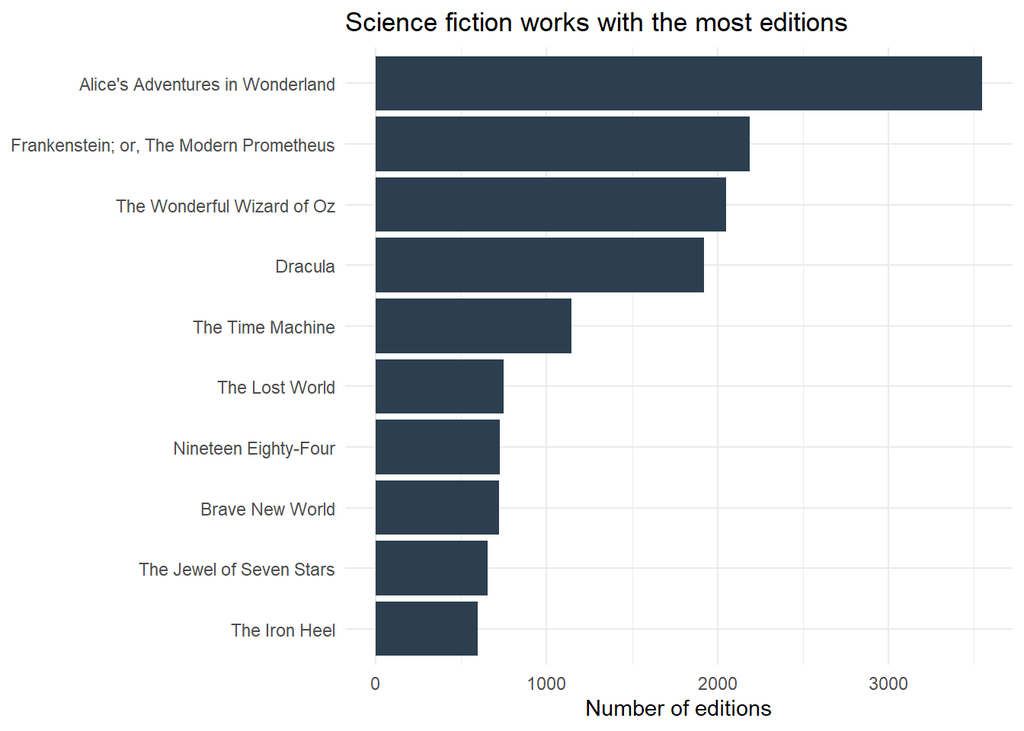

```r
works |>
  slice_head(n = 10) |>
  ggplot(aes(x = editions, y = fct_reorder(title, editions))) +
  geom_col(fill = "#2c3e50") +
  labs(
    title = "Science fiction works with the most editions",
    x = "Number of editions",
    y = NULL
  ) +
  theme_minimal()
```

### Does age relate to edition count?

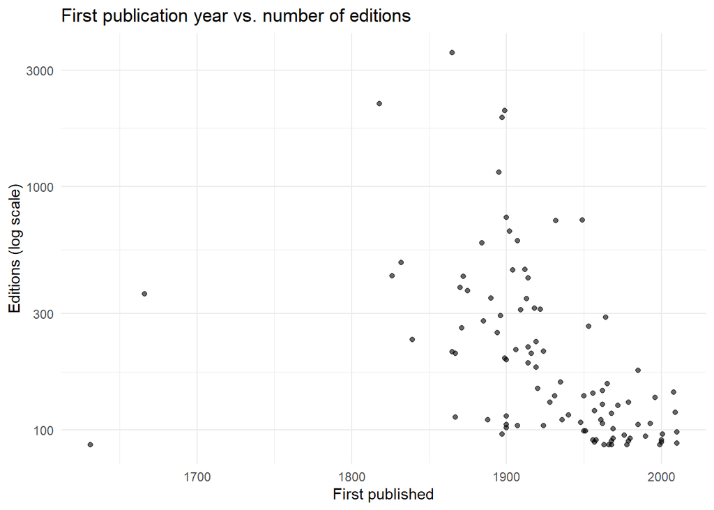

```r
works |>
  filter(!is.na(first_year)) |>
  ggplot(aes(first_year, editions)) +
  geom_point(alpha = 0.6) +
  scale_y_log10() +
  labs(
    title = "First publication year vs. number of editions",
    x = "First published",
    y = "Editions (log scale)"
  ) +
  theme_minimal()
```